# Untitled

Mitchell Holman

# 1 Introduction

This is an exploration of bicycle-sharing data in the city of Seattle, WA (USA) from October 2014 - August 2016. I hope to eventually combine this data with other forms of ride-sharing and transportation in the city, but this will be the first step.

Time to get started!

## 1.1 Loading Necessary Packages

```r
# For data manipulation and tidying
library(dplyr)
library(lubridate)
library(tidyr)

# For mapping
library(ggmap)
library(mapproj)
library(dplyr)
# For data visualizations
library(ggplot2)
library(gridExtra)

# For modeling and machine learning
library(caret)

library(readr)
```

## 1.2 Importing Data

All of the data can be downloaded from the bicycle-sharing service website or from [Kaggle](https://www.kaggle.com/pronto/cycle-share-dataset). This project contains 3 data sets and I’ll import and inspect each data file independently.

```r
station <- read.csv(file = "station.csv", header = TRUE,
    stringsAsFactors = FALSE)

trip <- read.csv(file = "trip.csv", header = TRUE,
    stringsAsFactors = FALSE)

weather <- read.csv(file = "weather.csv", header = TRUE,
    stringsAsFactors = FALSE)
```

Ok, let’s take a look at each of these data files.

## 1.3 Data Structures and Variables

$\bf station$

```r
str(station)
```

```
'data.frame':   58 obs. of  9 variables:
 $ station_id       : chr  "BT-01" "BT-03" "BT-04" "BT-05" ...
 $ name             : chr  "3rd Ave & Broad St" "2nd Ave & Vine St" "6th Ave & Blanchard St" "2nd Ave & Blanchard St" ...
 $ lat              : num  47.6 47.6 47.6 47.6 47.6 ...
 $ long             : num  -122 -122 -122 -122 -122 ...
 $ install_date     : chr  "10/13/2014" "10/13/2014" "10/13/2014" "10/13/2014" ...
 $ install_dockcount: int  18 16 16 14 20 18 20 20 20 18 ...
 $ modification_date: chr  "" "" "" "" ...
 $ current_dockcount: int  18 16 16 14 20 18 20 18 20 18 ...
 $ decommission_date: chr  "" "" "" "" ...
```

Looks like this dataset is dealing with 9 variables:

**Station ID :** The individual ID number for a bike station

**Name :** The name of that station ID, also appears to be the rough location of the station

**Latitude :** The latitude of the station

**Longitude :** The longitude of the station

**Install Date :** When that particular station was installed (in MM/DD/YYYY format)

**Install Dock Count :** Number of docks (bike positions) available at each station on installation day

**Modification Date :** When a particular station was modified (in MM/DD/YYYY format)

**Current Dock Count :** Number of docks (bike positions) available at each station on August 31, 2016

**Decommission Date :** The date that a particular station was put out of service (in MM/DD/YYYY format)

$\bf Trip$

```
'data.frame':   50793 obs. of  12 variables:
 $ trip_id          : int  431 432 433 434 435 436 437 438 439 440 ...
 $ starttime        : chr  "10/13/2014 10:31" "10/13/2014 10:32" "10/13/2014 10:33" "10/13/2014 10:34" ...
 $ stoptime         : chr  "10/13/2014 10:48" "10/13/2014 10:48" "10/13/2014 10:48" "10/13/2014 10:48" ...
 $ bikeid           : chr  "SEA00298" "SEA00195" "SEA00486" "SEA00333" ...
 $ tripduration     : num  986 926 884 866 924 ...
 $ from_station_name: chr  "2nd Ave & Spring St" "2nd Ave & Spring St" "2nd Ave & Spring St" "2nd Ave & Spring St" ...
 $ to_station_name  : chr  "Occidental Park / Occidental Ave S & S Washington St" "Occidental Park / Occidental Ave S & S Washington St" "Occidental Park / Occidental Ave S & S Washington St" "Occidental Park / Occidental Ave S & S Washington St" ...
 $ from_station_id  : chr  "CBD-06" "CBD-06" "CBD-06" "CBD-06" ...
 $ to_station_id    : chr  "PS-04" "PS-04" "PS-04" "PS-04" ...
 $ usertype         : chr  "Member" "Member" "Member" "Member" ...
 $ gender           : chr  "Male" "Male" "Female" "Female" ...
 $ birthyear        : int  1960 1970 1988 1977 1971 1974 1978 1983 1974 1958 ...
```

**Trip ID :** An identification number assigned to each trip (from one bike station to another)

**Start Time :** The time and date that a bike was borrowed from a station (in MM/DD/YYYY HH:MM format)

**Stop Time :** The time and date that a bike was returned to a station (in MM/DD/YYYY HH:MM format)

**Bike ID :** The identification number for a specific bike

**Trip Duration :** Time of trip (measured in seconds)

**From Station Name :** The name of the station where the bike was borrowed from

**To Station Name :** The name of the station where the bike was returned to

**From Station ID :** The ID number of the station where the bike was borrowed from

**To Station ID :** The ID number of the station where the bike was returned to

**User Type :** Indicates whether the user was a “Member” (i.e., someone with a monthly or annual membership to Pronto!) or a “Short-Term Pass Holder” (i.e., someone who purchased a 24 hour or 3 day pass)

**Gender :** The gender of the rider (if known)

**Birth Year :** The year that the rider was born

$\bf Weather$

```r
str(weather)
```

```
'data.frame':   689 obs. of  21 variables:
 $ Date                      : chr  "10/13/2014" "10/14/2014" "10/15/2014" "10/16/2014" ...
 $ Max_Temperature_F         : int  71 63 62 71 64 68 73 66 64 60 ...
 $ Mean_Temperature_F        : int  62 59 58 61 60 64 64 60 58 58 ...
 $ Min_TemperatureF          : int  54 55 54 52 57 59 55 55 55 57 ...
 $ Max_Dew_Point_F           : int  55 52 53 49 55 59 57 57 52 55 ...
 $ MeanDew_Point_F           : int  51 51 50 46 51 57 55 54 49 53 ...
 $ Min_Dewpoint_F            : int  46 50 46 42 41 55 53 50 46 48 ...
 $ Max_Humidity              : int  87 88 87 83 87 90 94 90 87 88 ...
 $ Mean_Humidity             : int  68 78 77 61 72 83 74 78 70 81 ...
 $ Min_Humidity              : int  46 63 67 36 46 68 52 67 58 67 ...
 $ Max_Sea_Level_Pressure_In : num  30 29.8 30 30 29.8 ...
 $ Mean_Sea_Level_Pressure_In: num  29.8 29.8 29.7 29.9 29.8 ...
 $ Min_Sea_Level_Pressure_In : num  29.6 29.5 29.5 29.8 29.7 ...
 $ Max_Visibility_Miles      : int  10 10 10 10 10 10 10 10 10 10 ...
 $ Mean_Visibility_Miles     : int  10 9 9 10 10 8 10 10 10 6 ...
 $ Min_Visibility_Miles      : int  4 3 3 10 6 2 6 5 6 2 ...
 $ Max_Wind_Speed_MPH        : int  13 10 18 9 8 10 10 12 15 14 ...
 $ Mean_Wind_Speed_MPH       : int  4 5 7 4 3 4 3 5 8 8 ...
 $ Max_Gust_Speed_MPH        : chr  "21" "17" "25" "-" ...
 $ Precipitation_In          : num  0 0.11 0.45 0 0.14 0.31 0 0.44 0.1 1.43 ...
 $ Events                    : chr  "Rain" "Rain" "Rain" "Rain" ...
```

This dataset represents quite a bit of weather data in 21 variables.

**Date :** The date in MM/DD/YYYY format

**Max Temperature F :** The maximum temperature that day (in degrees F)

**Mean Temperature F :** The average temperature that day (in degrees F)

**Min Temperature F :** The minimum temperature that day (in degrees F)

**Max Dew Point F :** The maximum dew point (in degrees F)

**Mean Dew Point F :** The average dew point (in degrees F)

**Min Dew Point F :** The minimum dew point (in degrees F)

**Max Humidity :** The maximum humidity (in %)

**Mean Humidity :** The average humidity (in %)

**Min Humidity :** The minimum humidity (in %)

**Maximum Sea Level Pressure :** The maximum atmospheric pressure at sea level (in inches of mercury)

**Mean Sea Level Pressure :** The average atmospheric pressure at sea level (in inches of mercury)

**Min Sea Level Pressure :** The minimum atmospheric pressure at sea level (in inches of mercury)

**Max Visibility Miles :** The maximum visibility (in miles)

**Mean Visibility Miles :** The average visibility (in miles)

**Min Visibility Miles :** The minimum visibility (in miles)

**Max Wind Speed MPH :** The maximum sustained wind speed (in miles per hour)

**Mean Wind Speed MPH :** The average sustained wind speed (in miles per hour)

**Max Gust Speed MPH :** The maximum gust wind speed (in miles per hour)

**Precipitation :** The amount of precipitation (measured in inches)

**Events :** Weather events that occurred that day (e.g., rain, fog, snow, thunderstorm etc.)

# 2 Data Visualizations

## 2.1 Exploring the Stations Dataset

Since the “Stations” dataset was the first one I imported, let’s start with a little exploration there. First of all, how many unique stations are we dealing with?

```r
station %>% summarise(n_distinct(station_id))
```

```
  n_distinct(station_id)
1                     58
```

Wow! 58 different stations! Let’s take a quick peek at where they are located.

[figure not shown]

```r
station_locs <- station %>% group_by(station_id) %>% select(1:4,-2)
mymap <- get_map(location = "Seattle", maptype = "roadmap", zoom = 12)
mymap1 <- get_map(location = c(lon =-122.315 , lat = 47.63), maptype = "roadmap", zoom = 13)
ggmap(mymap) + geom_point(aes(x = long, y = lat), data = station_locs,
    alpha = 0.7, color = "darkred", size = 2)
```

So it looks like all of the stations are located near the Lower Queen Anne, Belltown, International District, Capitol Hill and University of Washington areas. Let’s take a more zoomed-in look.

[figure not shown]

Great! So the locations are pretty well clustered. I wonder what order they were added in.

```r
station$install_date  <- mdy(station$install_date)


station %>% summarise(n_distinct(install_date))
```

```
  n_distinct(install_date)
1                        9
```

```r
station %>% group_by(install_date) %>% summarise(count = n()) %>%
    arrange(install_date)
```

```
# A tibble: 9 x 2
  install_date count
        <date> <int>
1   2014-10-13    50
2   2015-05-22     1
3   2015-06-12     1
4   2015-07-27     1
5   2015-09-15     1
6   2015-10-29     1
7   2016-03-18     1
8   2016-07-03     1
9   2016-08-09     1
```

Now, I wonder how many bikes can be parked at each station (as of August 31,2016)?

```r
5*5
```

[output not shown]

$\bf Change in Number of Bike Docks Per Station$

```r
dock_change <- station %>% group_by(station_id) %>% select(station_id,
    long, lat, ends_with("dockcount")) %>% mutate(dock_change = current_dockcount -
    install_dockcount)
dock_change %>%
group_by()
```

```
# A tibble: 58 x 6
   station_id      long      lat install_dockcount current_dockcount
        <chr>     <dbl>    <dbl>             <int>             <int>
 1      BT-01 -122.3510 47.61842                18                18
 2      BT-03 -122.3486 47.61583                16                16
 3      BT-04 -122.3411 47.61609                16                16
 4      BT-05 -122.3442 47.61311                14                14
 5     CBD-03 -122.3324 47.61073                20                20
 6     CBD-04 -122.3356 47.60922                18                18
 7     CBD-05 -122.3358 47.60406                20                20
 8     CBD-06 -122.3358 47.60595                20                18
 9     CBD-07 -122.3304 47.60351                20                20
10     CBD-13 -122.3396 47.61019                18                18
# ... with 48 more rows, and 1 more variables: dock_change <int>
```

[figure not shown]

```r
ggmap(mymap1) + geom_point(aes(x = long, y = lat, size = factor(dock_change), color = factor(dock_change)),
                           data = dock_change, alpha = 0.8) +
guides(color = guide_legend(title = "Change"), size = guide_legend(title = "Change")) +
scale_size_manual(values = 10:1)
```

[figure not shown]

```r
ggmap(mymap1) + geom_point(aes(x = long, y = lat, size = factor(current_dockcount), color = factor(current_dockcount)),
                           data = dock_change, alpha = 0.8) +
guides(color = guide_legend(title = "Current"), size = guide_legend(title = "Current")) +
scale_size_manual(values = 1:10)
```

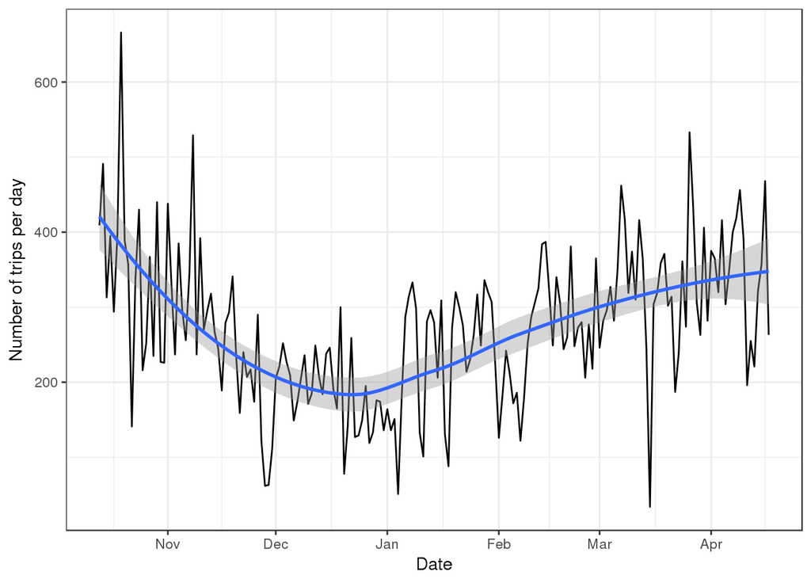

```r
trip_2 <- trip %>% mutate(start_dt = mdy_hm(starttime), stop_dt = mdy_hm(stoptime))

# Recode the dates
trip_2 <- trip_2 %>% mutate(start_date = paste(month(start_dt),
    day(start_dt), year(start_dt), sep = "/"))
trip_2$start_date <- mdy(trip_2$start_date)

trip_2 <- trip_2 %>% mutate(stop_date = paste(month(stop_dt),
    day(stop_dt), year(stop_dt), sep = "/"))
trip_2$stop_date <- mdy(trip_2$stop_date)

trip_2 %>%

  group_by(start_date) %>%

  summarize(N = n()) %>%

  ggplot(aes(x = start_date, y = N)) +

  geom_line() +

  labs(x = "Date", y = "Number of trips per day") +

  theme_bw() + geom_smooth()
```

```r
start_date_ym <- trip_2 %>% mutate(ym = paste(year(start_date),
    month(start_date), sep = "/"), Season = ifelse(ym %in% c("2014/10", "2014/11"), "Fall",
                                            ifelse(ym %in% c("2014/12","2015/1", "2015/2"), "Winter",
                                            ifelse(ym %in% c("2015/3", "2015/4", "2015/5"), "Spring", "Summer"))))
```

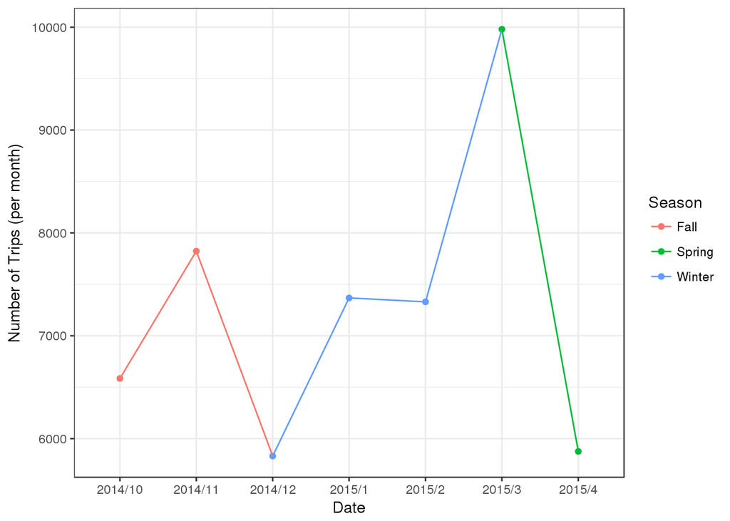

```r
start_date_ym %>%
  group_by(ym, Season) %>%
  summarize(N=n()) %>%
  ggplot(aes(x = ym, y = N, col = Season)) +
  geom_point() +
  geom_line(group = 1) +
  theme_bw() +
  labs(x = "Date", y = "Number of Trips (per month)")
```